# Block 1 ex 6

Facchin Tommaso

Consider the dataset `Davis` from the R package `carData`. The goal is to estimate the relationship between self‑reported weight (`repwt`) for men and women and measured weight (`weight`) for men and women.

```r
library(carData)
data(Davis)
head(Davis)
```

```
##   sex weight height repwt repht
## 1   M     77    182    77   180
## 2   F     58    161    51   159
## 3   F     53    161    54   158
## 4   M     68    177    70   175
## 5   F     59    157    59   155
## 6   M     76    170    76   165
```

### 1. Estimate three models of increasing complexity: one in which the relationship is assumed to be the same for both sexes; one in which the intercept is allowed to differ between sexes; and finally one in which both the intercept and the slope are allowed to differ between sexes.

```r
fit1 <- lm(repwt~weight, data=Davis)
fit2 <- lm(repwt~weight+sex, data=Davis)
fit3 <- lm(repwt~weight*sex, data=Davis)

summary(fit1)$coefficient
```

```
##               Estimate Std. Error   t value     Pr(>|t|)
## (Intercept) 15.7587338 2.49802689  6.308472 2.103459e-09
## weight       0.7529624 0.03675865 20.483950 5.102807e-49
```

```r
summary(fit2)$coefficient
```

```
##               Estimate Std. Error   t value     Pr(>|t|)
## (Intercept) 23.5204110 2.32791168 10.103653 2.696453e-19
## weight       0.5697807 0.03836794 14.850439 4.346960e-33
## sexM         9.7511292 1.17667585  8.287014 2.598776e-14
```

```r
summary(fit3)$coefficient
```

```
##                Estimate Std. Error    t value     Pr(>|t|)
## (Intercept)  41.3227620 2.16785082  19.061626 5.933960e-45
## weight        0.2644593 0.03631928   7.281515 1.007941e-11
## sexM        -39.9641221 3.92932151 -10.170744 1.823304e-19
## weight:sexM   0.7253627 0.05598043  12.957435 1.631447e-27
```

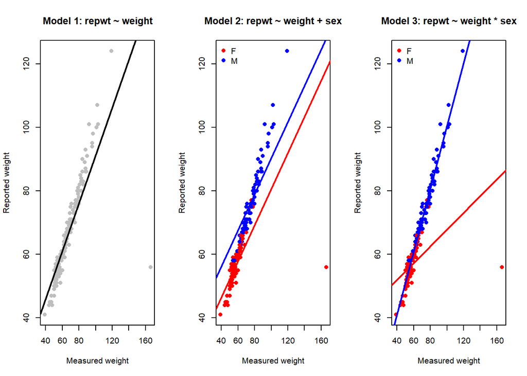

```r
par(mfrow = c(1, 3))

# Model 1
plot(Davis$weight, Davis$repwt, pch = 16, col = "grey",
     xlab = "Measured weight", ylab = "Reported weight",
     main = "Model 1: repwt ~ weight")
abline(fit1, col = "black", lwd = 2)

# Model 2
plot(Davis$weight, Davis$repwt, pch = 16,
     col = ifelse(Davis$sex == "M", "blue", "red"),
     xlab = "Measured weight", ylab = "Reported weight",
     main = "Model 2: repwt ~ weight + sex")

abline(a = coef(fit2)["(Intercept)"],
       b = coef(fit2)["weight"], col = "red", lwd = 2)
abline(a = coef(fit2)["(Intercept)"] + coef(fit2)["sexM"],
       b = coef(fit2)["weight"], col = "blue", lwd = 2)

legend("topleft", legend = c("F", "M"),
       col = c("red", "blue"), pch = 16, bty = "n")

# Model 3
plot(Davis$weight, Davis$repwt, pch = 16,
     col = ifelse(Davis$sex == "M", "blue", "red"),
     xlab = "Measured weight", ylab = "Reported weight",
     main = "Model 3: repwt ~ weight * sex")

abline(a = coef(fit3)["(Intercept)"],
       b = coef(fit3)["weight"], col = "red", lwd = 2)
abline(a = coef(fit3)["(Intercept)"] + coef(fit3)["sexM"],
       b = coef(fit3)["weight"] + coef(fit3)["weight:sexM"],
       col = "blue", lwd = 2)

legend("topleft", legend = c("F", "M"),
       col = c("red", "blue"), pch = 16, bty = "n")
```

### 2. Write the three models from point 1 explicitly in mathematical form, and compare their goodness of fit, indicating which model is chosen as the final model.

Model 1: same line for both sexes
$$\text{repwt}_i = \beta_0 + \beta_1 \,\text{weight}_i + \varepsilon_i$$

Model 2: different intercepts, same slope
$$\text{repwt}_i = \beta_0 + \beta_1 \,\text{weight}_i + \beta_2 \,
I(\text{sex}_i = M) + \varepsilon_i$$

Model 3: different intercepts and slopes
$$\text{repwt}_i = \beta_0 + \beta_1 \,\text{weight}_i + \beta_2 \,
I(\text{sex}_i = M)
+ \beta_3 \,\text{weight}_i \, I(\text{sex}_i = M) + \varepsilon_i$$

```r
summary(fit1)$adj.r.squared
```

```
## [1] 0.6969658
```

```r
summary(fit2)$adj.r.squared
```

```
## [1] 0.7794339
```

```r
summary(fit3)$adj.r.squared
```

```
## [1] 0.8855507
```

```r
anova(fit1, fit2, fit3)
```

```
## Analysis of Variance Table
##
## Model 1: repwt ~ weight
## Model 2: repwt ~ weight + sex
## Model 3: repwt ~ weight * sex
##   Res.Df     RSS Df Sum of Sq      F    Pr(>F)
## 1    181 10410.2
## 2    180  7535.3  1    2874.9 132.35 < 2.2e-16 ***
## 3    179  3888.3  1    3647.0 167.90 < 2.2e-16 ***
## ---
## Signif. codes:  0 '***' 0.001 '**' 0.01 '*' 0.05 '.' 0.1 ' ' 1
```

The ANOVA table shows that adding sex (Model 2 vs Model 1: F = 132.35, p < 2.2e−16) and then adding the interaction weight·sex (Model 3 vs Model 2: F = 167.90, p < 2.2e−16) both produce highly significant reductions in residual sum of squares. Consistently, the adjusted R² increases from Model 1 to Model 2 and further to Model 3, so Model 3, which allows both intercept and slope to differ by sex, is chosen as the final model.